# Tutorial 4: Learning From Others (Interactive Notebook)

Social learning strategies and the power of conformity

## How to use this notebook

Open `ScienceHighSchool.Rproj` first. Run each code block with the green **Run** button, or place your cursor in the code and press **Cmd/Ctrl + Enter**.

Change one small thing at a time. Then run the block again and look at the result.

## Word list（単語リスト）

| English | 日本語 | Meaning |
| --- | --- | --- |
| social learning | 社会学習 | learning by observing others |
| individual learning | 個人学習 | learning from your own experience |
| conformity | 同調 | following the majority more than proportionally |
| strategy | 戦略 | a rule for deciding what to do |
| majority | 多数派 | the option most people chose |

## Why copy others?

You arrive in a new town, hungry. Two ramen shops: one has a queue, one is empty. Where do you go?

Most people join the queue — and that is often *smart*. Other people’s choices contain **information**: they may know something you don’t. Humans are the champions of **social learning**; it is the foundation of culture, science, and TikTok trends alike.

But copying has a dark side, which we will discover in Tutorial 5. First, let’s give our agents the ability to watch each other.

## Setup

Load the model functions from `R/bandit_functions.R`. Tutorial 3 introduced `softmax()` and `simulate_learner()`. Today we will meet the new group functions in the same file.

```r
source("R/bandit_functions.R")
library(ggplot2)
set.seed(2026)
```

## How should you use the majority?

Suppose 10 agents played last round: **7 chose B, 3 chose A**. You get to peek before choosing. How strongly should the majority pull you?

One flexible rule: choose option $k$ with probability proportional to (number of people choosing $k$) raised to a power $\theta$ (theta):

$$p(\text{copy option } k) \propto (\text{count}_k)^{\,\theta}$$

`social_weights()` is a new helper function. In R, typing a function’s name without `()` shows its recipe instead of running it:

```r
social_weights
```

```
function (counts, theta = 1)
{
    w <- (counts + 0.1)^theta
    w/sum(w)
}
```

The first line of the recipe raises each count to the power $\theta$ (theta). The last line turns the weights into probabilities that add up to 1. The small `+ 0.1` keeps an option possible even when nobody chose it last time.

The exponent $\theta$ is the personality of the copier:

```r
counts <- c(3, 7)   # A was chosen 3 times, B was chosen 7 times
social_weights(counts, theta = 0)   # ignore popularity completely
```

```
[1] 0.5 0.5
```

```r
social_weights(counts, theta = 1)   # copy in proportion: 30% / 70%
```

```
[1] 0.3039216 0.6960784
```

```r
social_weights(counts, theta = 3)   # CONFORMITY: majority is exaggerated!
```

```
[1] 0.07683994 0.92316006
```

With $\theta = 3$, a 70% majority attracts about 92% of copiers. Following the majority *more than proportionally* is called **conformist-biased copying**, and experiments show humans (and even fish and some ants) often do exactly this.

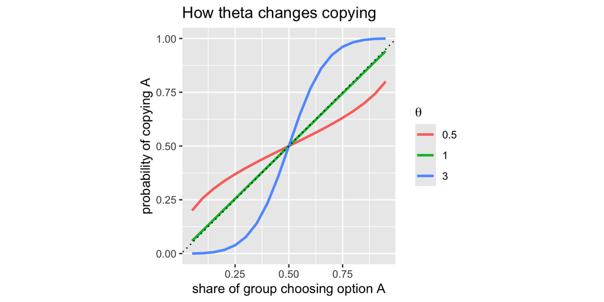

```r
grid <- expand.grid(share = seq(0.05, 0.95, by = 0.05),
                    theta = c(0.5, 1, 3))
grid$p_copy <- mapply(function(s, th) social_weights(c(10 * s, 10 * (1 - s)), th)[1],
                      grid$share, grid$theta)
ggplot(grid, aes(share, p_copy, color = factor(theta))) +
  geom_line(linewidth = 1) +
  geom_abline(slope = 1, intercept = 0, linetype = "dotted") +
  labs(title = "How theta changes copying",
       x = "share of group choosing option A",
       y = "probability of copying A",
       color = expression(theta)) +
  coord_equal()
```

The dotted line is proportional copying. Above it (steep S-shape, $\theta=3$): conformity. Below it ($\theta=0.5$): the majority is *weakened*.

## A society of learners

Now the main event. We put **many agents in the same world**. Each agent mixes two sources of information:

- its **own experience** (the Q values from Tutorial 3), and
- **what the group did** on the previous round (the social weights above).

One number, $\sigma$ (sigma, from 0 to 1), sets the mix:

$$p(\text{choice}) = (1 - \sigma) \times p_{\text{individual}} \;+\;
\sigma \times p_{\text{social}}$$

- $\sigma = 0$: pure individual learner — ignores everybody
- $\sigma = 1$: pure copier — never uses its own experience
- in between: a bit of both (like most of us!)

The function `simulate_group()` in `R/bandit_functions.R` implements this. Open the file and read it — you already know every ingredient!

We use a difficult world here. Option A pays 30% of the time. Option B pays 50% of the time. The small difference makes it hard for one agent to discover which option is better.

```r
sim <- simulate_group(n_agents = 10, n_trials = 100,
                      reward_probs = c(0.3, 0.5),
                      alpha = 0.3, beta = 5,
                      sigma = 0.3, theta = 2)
head(sim)
```

|  | trial | agent | choice | reward | best | alpha | beta | sigma | theta |
| --- | --- | --- | --- | --- | --- | --- | --- | --- | --- |
| 1 | 1 | 1 | 1 | 0 | 2 | 0.3 | 5 | 0.3 | 2 |
| 2 | 2 | 1 | 2 | 0 | 2 | 0.3 | 5 | 0.3 | 2 |
| 3 | 3 | 1 | 2 | 1 | 2 | 0.3 | 5 | 0.3 | 2 |
| 4 | 4 | 1 | 2 | 1 | 2 | 0.3 | 5 | 0.3 | 2 |
| 5 | 5 | 1 | 2 | 1 | 2 | 0.3 | 5 | 0.3 | 2 |
| 6 | 6 | 1 | 2 | 1 | 2 | 0.3 | 5 | 0.3 | 2 |

Each row = one agent on one trial. Let’s watch the whole group at once:

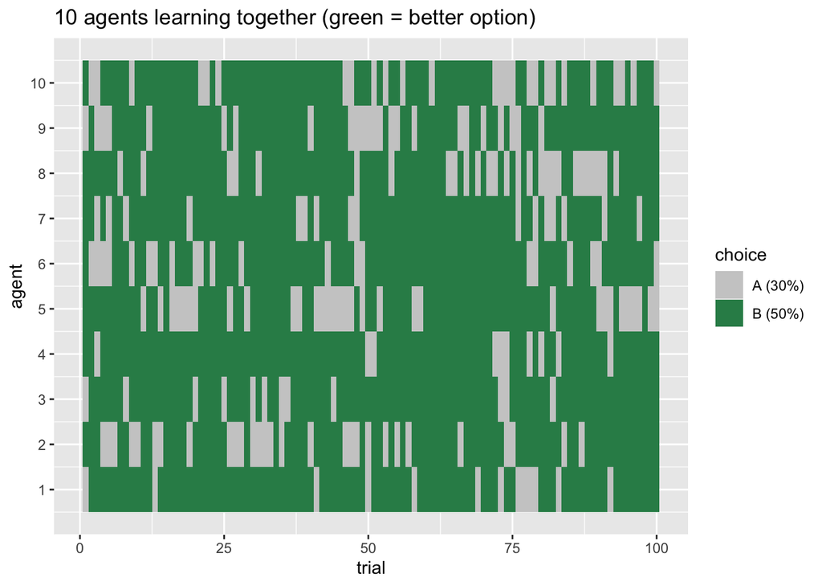

```r
ggplot(sim, aes(x = trial, y = agent, fill = factor(choice))) +
  geom_tile() +
  scale_fill_manual(values = c("1" = "grey80", "2" = "seagreen"),
                    name = "choice", labels = c("A (30%)", "B (50%)")) +
  scale_y_continuous(breaks = 1:10) +
  labs(title = "10 agents learning together (green = better option)")
```

Green spreads through the group like a rumour. That is culture, in miniature.

## Does copying help?

Let’s compare societies with different amounts of social learning. `average_performance()` runs the simulation many times and reports, for each trial, the fraction of agents choosing the better option:

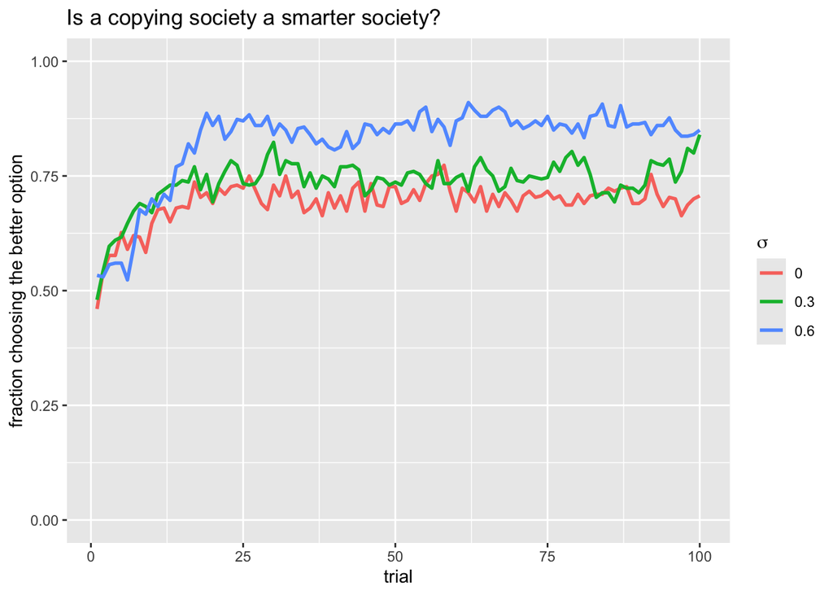

```r
mix <- do.call(rbind, lapply(c(0, 0.3, 0.6), function(s) {
  perf <- average_performance(n_reps = 30, n_agents = 10, n_trials = 100,
                              reward_probs = c(0.3, 0.5),
                              alpha = 0.3, beta = 5,
                              sigma = s, theta = 2)
  transform(perf, sigma = s)
}))

ggplot(mix, aes(trial, correct, color = factor(sigma))) +
  geom_line(linewidth = 1) +
  ylim(0, 1) +
  labs(title = "Is a copying society a smarter society?",
       y = "fraction choosing the better option",
       color = expression(sigma))
```

Look carefully: societies with moderate copying ($\sigma = 0.3$–$0.6$) typically end up **better than pure individual learners**. Copying spreads good discoveries quickly, and the majority filters out individual mistakes. Group intelligence for free!

…or is it? (Cliffhanger for Tutorial 5.)

## Try it! — explore the society

1. **Big city vs small village**: run the comparison with `n_agents = 3` and `n_agents = 30`. Does group size change how much copying helps?
2. **Weak majority or minority seeking?** Set `theta = 0.5` first. This still favours the majority, but weakly. Then set `theta = -1`, which favours the minority. How does each society perform?
3. **The pure-copier trap**: try `sigma = 0.95`. Watch the tile plot from earlier — what goes wrong? Can a group learn if almost nobody collects their own information?

## The big idea

$\sigma$ (how much to copy) and $\theta$ (how strongly to follow majorities) are **social learning strategies**. Evolution, development, and culture all tune these knobs. A central question in current research — including at RIKEN and in the COSMOS summer school — is: *which strategies are smart, and when?* Later today, your group will investigate part of that question.

## Optional appendix: agents can be different

So far, every agent has had the same $\alpha$ (alpha), $\beta$ (beta), $\sigma$ (sigma), and $\theta$ (theta). Real people have **individual differences**（個人差）, also called **heterogeneity**.

`simulate_group()` can take one value per agent for any of these parameters. First, here are different individual-learning parameters:

```r
alpha_by_agent <- rep(c(0.1, 0.7), each = 6)
beta_by_agent <- rep(c(2, 8), each = 3, times = 2)

set.seed(2026)
mixed_agents <- simulate_group(
  n_agents = 12, n_trials = 100, reward_probs = c(0.3, 0.5),
  alpha = alpha_by_agent, beta = beta_by_agent,
  sigma = 0.3, theta = 2)
aggregate(reward ~ alpha + beta, data = mixed_agents, FUN = mean)
```

| alpha | beta | reward |
| --- | --- | --- |
| 0.1 | 2 | 0.4200000 |
| 0.7 | 2 | 0.4133333 |
| 0.1 | 8 | 0.4833333 |
| 0.7 | 8 | 0.4400000 |

Here, agents have different combinations of learning speed and exploration. Predict which type will earn more. One run is noisy, so repeat the simulation many times before you make a conclusion.

## Group-project seed: a mixed society

What if eight agents balance individual and social learning, but two agents are strong conformists? Predict before running: can two conformists pull the whole group toward a herd?

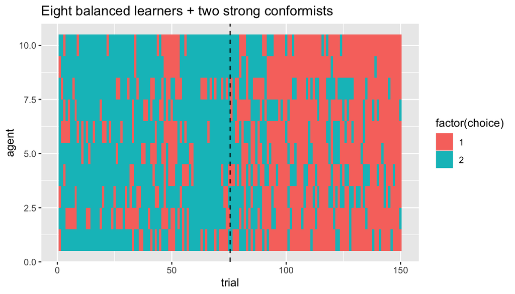

```r
sigma_by_agent <- c(rep(0.4, 8), rep(0.9, 2))
theta_by_agent <- c(rep(1, 8), rep(4, 2))

set.seed(2026)
mixed_social <- simulate_group(
  n_agents = 10, n_trials = 150, reward_probs = c(0.3, 0.5),
  sigma = sigma_by_agent, theta = theta_by_agent, change_point = 76)
ggplot(mixed_social, aes(trial, agent, fill = factor(choice))) +
  geom_tile() + geom_vline(xintercept = 75.5, linetype = "dashed") +
  labs(title = "Eight balanced learners + two strong conformists")
```

Compare this mixed society with a society where everyone has `sigma = 0.4` and `theta = 1`. Try changing the number of conformists. Does your answer change in a stable world (`change_point = NA`)? This could become your group project.

## What you learned

- Other people’s behaviour is information; copying is often rational
- $\theta$: proportional imitation vs **conformity** (exaggerating majorities)
- $\sigma$: the balance between own experience and social information
- Moderate copying can make the whole group smarter

Next tutorial: when crowds are wise, when they go mad — and how to tell the difference.